# Ford GoBike System Analysis

## Preliminary Wrangling

> I'll be investigating the Ford GoBike data set for the 2017 period between June and December.

```python
# import all packages and set plots to be embedded inline
import numpy as np
import pandas as pd
import matplotlib.pyplot as plt
import seaborn as sb

%matplotlib inline
```

```python
gobike_df = pd.read_csv("2017-fordgobike-tripdata.csv")
```

```python
gobike_df.head()
```

|  | duration_sec | start_time | end_time | start_station_id | start_station_name | start_station_latitude | start_station_longitude | end_station_id | end_station_name | end_station_latitude | end_station_longitude | bike_id | user_type | member_birth_year | member_gender |
| --- | --- | --- | --- | --- | --- | --- | --- | --- | --- | --- | --- | --- | --- | --- | --- |
| 0 | 80110 | 2017-12-31 16:57:39.6540 | 2018-01-01 15:12:50.2450 | 74 | Laguna St at Hayes St | 37.776435 | -122.426244 | 43 | San Francisco Public Library (Grove St at Hyde... | 37.778768 | -122.415929 | 96 | Customer | 1987.0 | Male |
| 1 | 78800 | 2017-12-31 15:56:34.8420 | 2018-01-01 13:49:55.6170 | 284 | Yerba Buena Center for the Arts (Howard St at ... | 37.784872 | -122.400876 | 96 | Dolores St at 15th St | 37.766210 | -122.426614 | 88 | Customer | 1965.0 | Female |
| 2 | 45768 | 2017-12-31 22:45:48.4110 | 2018-01-01 11:28:36.8830 | 245 | Downtown Berkeley BART | 37.870348 | -122.267764 | 245 | Downtown Berkeley BART | 37.870348 | -122.267764 | 1094 | Customer | NaN | NaN |
| 3 | 62172 | 2017-12-31 17:31:10.6360 | 2018-01-01 10:47:23.5310 | 60 | 8th St at Ringold St | 37.774520 | -122.409449 | 5 | Powell St BART Station (Market St at 5th St) | 37.783899 | -122.408445 | 2831 | Customer | NaN | NaN |
| 4 | 43603 | 2017-12-31 14:23:14.0010 | 2018-01-01 02:29:57.5710 | 239 | Bancroft Way at Telegraph Ave | 37.868813 | -122.258764 | 247 | Fulton St at Bancroft Way | 37.867789 | -122.265896 | 3167 | Subscriber | 1997.0 | Female |

```python
gobike_df.info()
```

```
<class 'pandas.core.frame.DataFrame'>
RangeIndex: 519700 entries, 0 to 519699
Data columns (total 15 columns):
 #   Column                   Non-Null Count   Dtype
---  ------                   --------------   -----
 0   duration_sec             519700 non-null  int64
 1   start_time               519700 non-null  object
 2   end_time                 519700 non-null  object
 3   start_station_id         519700 non-null  int64
 4   start_station_name       519700 non-null  object
 5   start_station_latitude   519700 non-null  float64
 6   start_station_longitude  519700 non-null  float64
 7   end_station_id           519700 non-null  int64
 8   end_station_name         519700 non-null  object
 9   end_station_latitude     519700 non-null  float64
 10  end_station_longitude    519700 non-null  float64
 11  bike_id                  519700 non-null  int64
 12  user_type                519700 non-null  object
 13  member_birth_year        453159 non-null  float64
 14  member_gender            453238 non-null  object
dtypes: float64(5), int64(4), object(6)
memory usage: 59.5+ MB
```

```python
gobike_df.describe()
```

|  | duration_sec | start_station_id | start_station_latitude | start_station_longitude | end_station_id | end_station_latitude | end_station_longitude | bike_id | member_birth_year |
| --- | --- | --- | --- | --- | --- | --- | --- | --- | --- |
| count | 519700.000000 | 519700.000000 | 519700.000000 | 519700.000000 | 519700.000000 | 519700.000000 | 519700.000000 | 519700.000000 | 453159.000000 |
| mean | 1099.009521 | 95.034245 | 37.771653 | -122.363927 | 92.184041 | 37.771844 | -122.363236 | 1672.533079 | 1980.404787 |
| std | 3444.146451 | 86.083078 | 0.086305 | 0.105573 | 84.969491 | 0.086224 | 0.105122 | 971.356959 | 10.513488 |
| min | 61.000000 | 3.000000 | 37.317298 | -122.444293 | 3.000000 | 37.317298 | -122.444293 | 10.000000 | 1886.000000 |
| 25% | 382.000000 | 24.000000 | 37.773492 | -122.411726 | 23.000000 | 37.774520 | -122.410345 | 787.000000 | 1974.000000 |
| 50% | 596.000000 | 67.000000 | 37.783521 | -122.398870 | 66.000000 | 37.783830 | -122.398525 | 1728.500000 | 1983.000000 |
| 75% | 938.000000 | 139.000000 | 37.795392 | -122.391034 | 134.000000 | 37.795392 | -122.391034 | 2520.000000 | 1988.000000 |
| max | 86369.000000 | 340.000000 | 37.880222 | -121.874119 | 340.000000 | 37.880222 | -121.874119 | 3733.000000 | 1999.000000 |

```python
gobike_df.shape
```

```
(519700, 15)
```

```python
gobike_df.isnull().sum()
```

```
duration_sec                   0
start_time                     0
end_time                       0
start_station_id               0
start_station_name             0
start_station_latitude         0
start_station_longitude        0
end_station_id                 0
end_station_name               0
end_station_latitude           0
end_station_longitude          0
bike_id                        0
user_type                      0
member_birth_year          66541
member_gender              66462
dtype: int64
```

```python
gobike_df.duplicated().value_counts()
```

```
False    519700
dtype: int64
```

# Initial Wrangling

1. Change start_time and end_time to datetime data type
2. Add a column for month, hour, day, member_age
3. Add a column for duration in minutes
4. Drop the rows with missing data
5. Drop columns that I'm not interested in
6. Add member age column

```python
# Let's make a copy to clean
gobike_clean = gobike_df.copy()
```

```python
# Drop rows with no member_birth_year or member_gender
gobike_clean.dropna(inplace=True)
```

```python
gobike_clean.shape
```

```
(453159, 15)
```

```python
# Drop columns I'll not bee needing for the analysis
gobike_clean.drop(['start_station_latitude', 'start_station_longitude', 'end_station_latitude', 'end_station_longitude'], axis = 1, inplace=True)
```

```python
gobike_clean.info()
```

```
<class 'pandas.core.frame.DataFrame'>
Int64Index: 453159 entries, 0 to 519699
Data columns (total 11 columns):
 #   Column              Non-Null Count   Dtype
---  ------              --------------   -----
 0   duration_sec        453159 non-null  int64
 1   start_time          453159 non-null  object
 2   end_time            453159 non-null  object
 3   start_station_id    453159 non-null  int64
 4   start_station_name  453159 non-null  object
 5   end_station_id      453159 non-null  int64
 6   end_station_name    453159 non-null  object
 7   bike_id             453159 non-null  int64
 8   user_type           453159 non-null  object
 9   member_birth_year   453159 non-null  float64
 10  member_gender       453159 non-null  object
dtypes: float64(1), int64(4), object(6)
memory usage: 41.5+ MB
```

```python
#Change start_time and end_time to datetime data type
gobike_clean['start_time'] =  pd.to_datetime(gobike_clean['start_time'], infer_datetime_format=True)
gobike_clean['end_time'] =  pd.to_datetime(gobike_clean['end_time'], infer_datetime_format=True)
```

```python
gobike_clean.info()
```

```
<class 'pandas.core.frame.DataFrame'>
Int64Index: 453159 entries, 0 to 519699
Data columns (total 11 columns):
 #   Column              Non-Null Count   Dtype
---  ------              --------------   -----
 0   duration_sec        453159 non-null  int64
 1   start_time          453159 non-null  datetime64[ns]
 2   end_time            453159 non-null  datetime64[ns]
 3   start_station_id    453159 non-null  int64
 4   start_station_name  453159 non-null  object
 5   end_station_id      453159 non-null  int64
 6   end_station_name    453159 non-null  object
 7   bike_id             453159 non-null  int64
 8   user_type           453159 non-null  object
 9   member_birth_year   453159 non-null  float64
 10  member_gender       453159 non-null  object
dtypes: datetime64[ns](2), float64(1), int64(4), object(4)
memory usage: 41.5+ MB
```

```python
# Add some new columns for month, day, hour, member_age
gobike_clean['start_month'] = pd.DatetimeIndex(gobike_clean['start_time']).month
gobike_clean['start_time_dayofweek']= gobike_clean['start_time'].dt.strftime('%a')
gobike_clean['start_time_hour']= gobike_clean['start_time'].dt.hour
gobike_clean['user_age'] = 2017 - gobike_clean['member_birth_year']
```

```python
# Map the abbreviated month names onto the start_month column
d = {1:'Jan', 2:'Feb', 3:'Mar', 4:'Apr', 5:"May",
     6: "Jun", 7:"Jul", 8:"Aug", 9:"Sep", 10:"Oct", 11:"Nov", 12:"Dec"}

gobike_clean.start_month = gobike_clean.start_month.map(d)
```

```python
gobike_clean.head()
```

|  | duration_sec | start_time | end_time | start_station_id | start_station_name | end_station_id | end_station_name | bike_id | user_type | member_birth_year | member_gender | start_month | start_time_dayofweek | start_time_hour | user_age |
| --- | --- | --- | --- | --- | --- | --- | --- | --- | --- | --- | --- | --- | --- | --- | --- |
| 0 | 80110 | 2017-12-31 16:57:39.654 | 2018-01-01 15:12:50.245 | 74 | Laguna St at Hayes St | 43 | San Francisco Public Library (Grove St at Hyde... | 96 | Customer | 1987.0 | Male | Dec | Sun | 16 | 30.0 |
| 1 | 78800 | 2017-12-31 15:56:34.842 | 2018-01-01 13:49:55.617 | 284 | Yerba Buena Center for the Arts (Howard St at ... | 96 | Dolores St at 15th St | 88 | Customer | 1965.0 | Female | Dec | Sun | 15 | 52.0 |
| 4 | 43603 | 2017-12-31 14:23:14.001 | 2018-01-01 02:29:57.571 | 239 | Bancroft Way at Telegraph Ave | 247 | Fulton St at Bancroft Way | 3167 | Subscriber | 1997.0 | Female | Dec | Sun | 14 | 20.0 |
| 6 | 4507 | 2017-12-31 23:49:28.422 | 2018-01-01 01:04:35.619 | 259 | Addison St at Fourth St | 259 | Addison St at Fourth St | 3539 | Customer | 1991.0 | Female | Dec | Sun | 23 | 26.0 |
| 12 | 2183 | 2017-12-31 23:52:55.581 | 2018-01-01 00:29:18.743 | 67 | San Francisco Caltrain Station 2 (Townsend St... | 24 | Spear St at Folsom St | 2311 | Subscriber | 1990.0 | Male | Dec | Sun | 23 | 27.0 |

```python
# Create a new column for converted duration seconds into minuets
gobike_clean['duration_min'] = gobike_clean['duration_sec']/60
gobike_clean['duration_min'] = gobike_clean['duration_min'].astype(int)
gobike_clean.head()
```

|  | duration_sec | start_time | end_time | start_station_id | start_station_name | end_station_id | end_station_name | bike_id | user_type | member_birth_year | member_gender | start_month | start_time_dayofweek | start_time_hour | user_age | duration_min |
| --- | --- | --- | --- | --- | --- | --- | --- | --- | --- | --- | --- | --- | --- | --- | --- | --- |
| 0 | 80110 | 2017-12-31 16:57:39.654 | 2018-01-01 15:12:50.245 | 74 | Laguna St at Hayes St | 43 | San Francisco Public Library (Grove St at Hyde... | 96 | Customer | 1987.0 | Male | Dec | Sun | 16 | 30.0 | 1335 |
| 1 | 78800 | 2017-12-31 15:56:34.842 | 2018-01-01 13:49:55.617 | 284 | Yerba Buena Center for the Arts (Howard St at ... | 96 | Dolores St at 15th St | 88 | Customer | 1965.0 | Female | Dec | Sun | 15 | 52.0 | 1313 |
| 4 | 43603 | 2017-12-31 14:23:14.001 | 2018-01-01 02:29:57.571 | 239 | Bancroft Way at Telegraph Ave | 247 | Fulton St at Bancroft Way | 3167 | Subscriber | 1997.0 | Female | Dec | Sun | 14 | 20.0 | 726 |
| 6 | 4507 | 2017-12-31 23:49:28.422 | 2018-01-01 01:04:35.619 | 259 | Addison St at Fourth St | 259 | Addison St at Fourth St | 3539 | Customer | 1991.0 | Female | Dec | Sun | 23 | 26.0 | 75 |
| 12 | 2183 | 2017-12-31 23:52:55.581 | 2018-01-01 00:29:18.743 | 67 | San Francisco Caltrain Station 2 (Townsend St... | 24 | Spear St at Folsom St | 2311 | Subscriber | 1990.0 | Male | Dec | Sun | 23 | 27.0 | 36 |

```python
gobike_clean['user_age'].describe()
```

```
count    453159.000000
mean         36.595213
std          10.513488
min          18.000000
25%          29.000000
50%          34.000000
75%          43.000000
max         131.000000
Name: user_age, dtype: float64
```

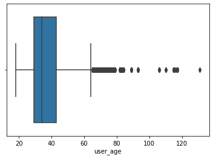

```python
sb.boxplot(data = gobike_clean, x = 'user_age');
```

There are many outliers here with ages that seem unlikely.

```python
gobike_clean['user_age'].median()
```

```
34.0
```

```python
# Let's remove outliners. Only keep record with user_age 65 and below.
gobike_clean = gobike_clean[gobike_clean['user_age'] <= 65]
```

```python
gobike_clean.head()
```

|  | duration_sec | start_time | end_time | start_station_id | start_station_name | end_station_id | end_station_name | bike_id | user_type | member_birth_year | member_gender | start_month | start_time_dayofweek | start_time_hour | user_age | duration_min |
| --- | --- | --- | --- | --- | --- | --- | --- | --- | --- | --- | --- | --- | --- | --- | --- | --- |
| 0 | 80110 | 2017-12-31 16:57:39.654 | 2018-01-01 15:12:50.245 | 74 | Laguna St at Hayes St | 43 | San Francisco Public Library (Grove St at Hyde... | 96 | Customer | 1987.0 | Male | Dec | Sun | 16 | 30.0 | 1335 |
| 1 | 78800 | 2017-12-31 15:56:34.842 | 2018-01-01 13:49:55.617 | 284 | Yerba Buena Center for the Arts (Howard St at ... | 96 | Dolores St at 15th St | 88 | Customer | 1965.0 | Female | Dec | Sun | 15 | 52.0 | 1313 |
| 4 | 43603 | 2017-12-31 14:23:14.001 | 2018-01-01 02:29:57.571 | 239 | Bancroft Way at Telegraph Ave | 247 | Fulton St at Bancroft Way | 3167 | Subscriber | 1997.0 | Female | Dec | Sun | 14 | 20.0 | 726 |
| 6 | 4507 | 2017-12-31 23:49:28.422 | 2018-01-01 01:04:35.619 | 259 | Addison St at Fourth St | 259 | Addison St at Fourth St | 3539 | Customer | 1991.0 | Female | Dec | Sun | 23 | 26.0 | 75 |
| 12 | 2183 | 2017-12-31 23:52:55.581 | 2018-01-01 00:29:18.743 | 67 | San Francisco Caltrain Station 2 (Townsend St... | 24 | Spear St at Folsom St | 2311 | Subscriber | 1990.0 | Male | Dec | Sun | 23 | 27.0 | 36 |

```python
# save cleaned data
gobike_clean.to_csv('clean_master_file.csv', index=False)
```

### What is/are the main feature(s) of interest in your dataset?

I'll be most interested in looking into usage levels across the start hours, start day and start month

### What features in the dataset do you think will help support your investigation into your feature(s) of interest?

Some of the following areas will help in my investigation.

- member_gender
- start_month
- start_time_hour
- start_time_dayofweek
- user_type
- user_age

## Univariate Exploration

Let's take a look at the distribution of user_age

```python
gobike_clean['user_age'].describe()
```

```
count    448489.000000
mean         36.205064
std           9.749593
min          18.000000
25%          29.000000
50%          34.000000
75%          42.000000
max          65.000000
Name: user_age, dtype: float64
```

```python
gobike_clean.shape
```

```
(448489, 16)
```

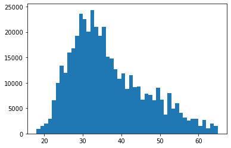

```python
binsize = 1
bins = np.arange(18, gobike_clean['user_age'].max()+binsize, binsize)
plt.hist(data = gobike_clean, x = 'user_age', bins = bins);
```

Let's take a look at the distribution of start month

```python
gobike_clean['start_month'].value_counts()
```

```
Oct    94375
Nov    85270
Sep    84678
Dec    77310
Aug    69057
Jul    35447
Jun     2352
Name: start_month, dtype: int64
```

```python
# Let's convert the start_month into ordinal variables.
month = ['Jun','Jul','Aug','Sep','Oct', 'Nov', 'Dec']
ordered_month = pd.api.types.CategoricalDtype(ordered = True, categories = month)
gobike_clean['start_month'] = gobike_clean['start_month'].astype(ordered_month)
```

```python
default_color = sb.color_palette()[0]
```

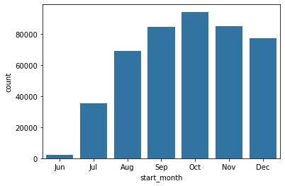

```python
sb.countplot(data = gobike_clean, x = 'start_month', color= default_color);
```

##### As we can see from the above countplot there is a peak in October - having investigated the low numbers of June we see that the GoBikes only began operating in San Francisco in June.

Let's take a looka t the distribution across start hour

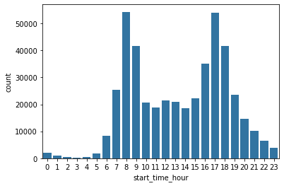

```python
sb.countplot(data = gobike_clean, x = 'start_time_hour', color= default_color);
```

##### The graph above shows us that there are peaks at 8am and 5pm with a drop off during the middle of the day.

Let's take a look at the distribution across the day of the week

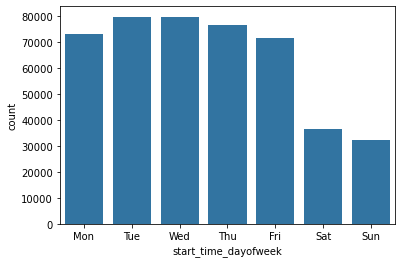

```python
weekdays = ['Mon','Tue','Wed','Thu','Fri', 'Sat', 'Sun']
ordered_weekdays = pd.api.types.CategoricalDtype(ordered = True, categories = weekdays)
gobike_clean['start_time_dayofweek'] = gobike_clean['start_time_dayofweek'].astype(ordered_weekdays)

sb.countplot(data = gobike_clean, x = 'start_time_dayofweek', color= default_color);
```

##### As the above shows there are some similar levels during the working with a significant drop off at the weekend

```python
gobike_clean['start_time_dayofweek'].value_counts()
```

```
Tue    79631
Wed    79589
Thu    76343
Mon    72849
Fri    71353
Sat    36301
Sun    32423
Name: start_time_dayofweek, dtype: int64
```

#### Tuesday and Wednesday see the highest usage with weekday usage being around twice as much as the weekend

Let's take a look at the split across gender

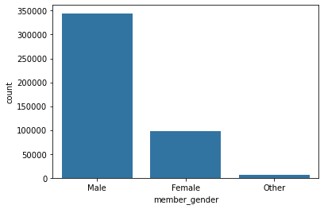

```python
sb.countplot(data = gobike_clean, x = 'member_gender', color = default_color);
```

##### The vast majority of users are male

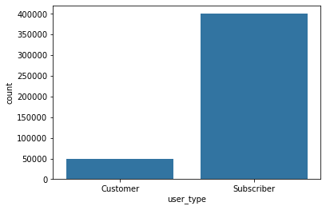

```python
sb.countplot(data = gobike_clean, x = 'user_type', color = default_color);
```

##### Sucbscibers are the vast majority here - subscribers are 8x more prevalent than customers

Let's take a look at ride duration in minutes

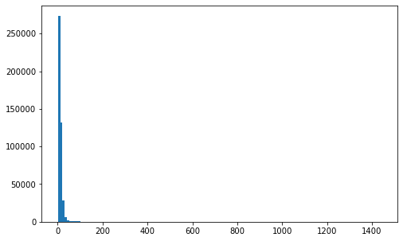

```python
binsize = 10
bins = np.arange(1, gobike_clean['duration_min'].max()+binsize, binsize)

plt.figure(figsize=[8, 5])

plt.hist(data = gobike_clean, x = 'duration_min', bins=bins);
```

##### There's an extremley long tail to the above graph - let's set limits on the x axis.

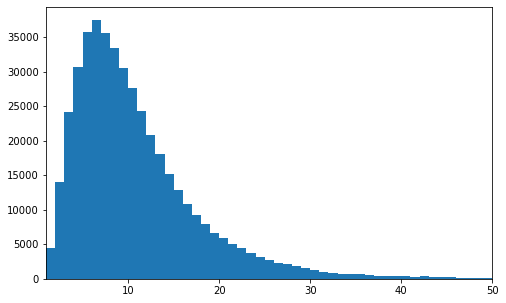

```python
binsize = 1
bins = np.arange(0, gobike_clean['duration_min'].max()+binsize, binsize)

plt.figure(figsize=[8, 5])

plt.hist(data = gobike_clean, x = 'duration_min', bins=bins)
plt.xlim(1,50);
```

##### By limiting the the xaxis we get a clearer picture of the duration of rides.

```python
gobike_clean['duration_min'].median()
```

```
9.0
```

```python
gobike_clean['duration_min'].describe()
```

```
count    448489.000000
mean         13.388114
std          42.084312
min           1.000000
25%           6.000000
50%           9.000000
75%          13.000000
max        1437.000000
Name: duration_min, dtype: float64
```

### Discuss the distribution(s) of your variable(s) of interest. Were there any unusual points? Did you need to perform any transformations?

- There was an unusual max age of 131 and some unusually high age outliers
- Mean age of riders is 36
- Peak usage in October - having done some research we see that Go bikes only began operating in San Feancisco in June which would likely account for the low numbers in this month.
- There are peaks in usage at 8am and 5pm
- Tueaday is the highest day for usage only slight ahead of Wednesday and weekdays are much higher than weekends.
- Vast majority of users are male rather than female
- Subscribers are 8x more prevalent than customers
- Mean ride time is 13 mins.

### Of the features you investigated, were there any unusual distributions? Did you perform any operations on the data to tidy, adjust, or change the form of the data? If so, why did you do this?

- There was a long-tail in the usage minutes and so I limited the x axis to 50 which gave a far better picture of distribution.
- With age there was some clear issues with age and so after dropping all ages above 65 we were better able to see the distribution of age.

## Bivariate Exploration

#### Let's take a look at gender and start month

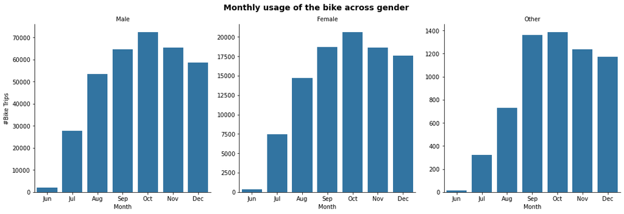

```python
# start month and gender
g = sb.catplot(data=gobike_clean, x='start_month', col="member_gender", kind='count', sharey = False,
            color = default_color)
g.set_axis_labels("Month", "#Bike Trips")
g.set_titles("{col_name}")
g.fig.suptitle('Monthly usage of the bike across gender', y=1.03, fontsize=14, fontweight='semibold');
```

##### Across gender there is a general trend which is followed and so there is not too much info to pull out from this

Let's take a look at gender and start_hour

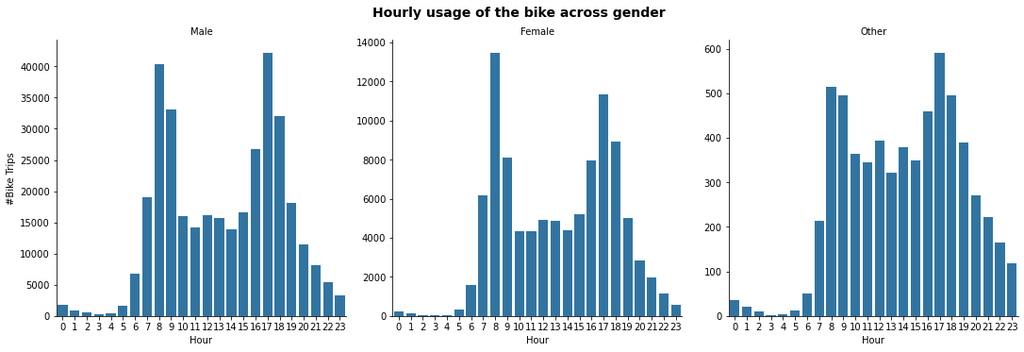

```python
g = sb.catplot(data=gobike_clean, x='start_time_hour', col="member_gender", kind='count', sharey = False,
            color = default_color)
g.set_axis_labels("Hour", "#Bike Trips")
g.set_titles("{col_name}")
g.fig.suptitle('Hourly usage of the bike across gender', y=1.03, fontsize=14, fontweight='semibold');
```

##### Again similar to the previous graph there is a general trend and peaks at 8am and 5pm

Let's take a look at gender and day of week

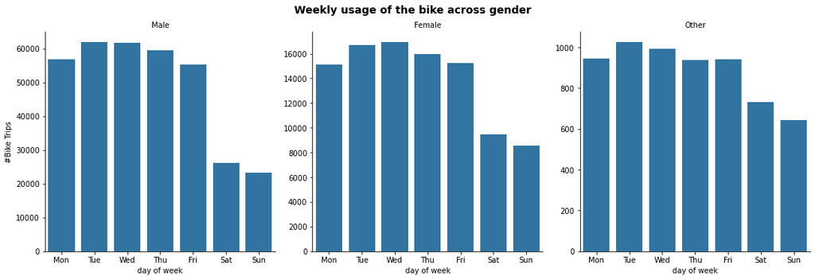

```python
g = sb.catplot(data=gobike_clean, x='start_time_dayofweek', col="member_gender", kind='count', sharey = False,
            color = default_color)
g.set_axis_labels("day of week", "#Bike Trips")
g.set_titles("{col_name}")
g.fig.suptitle('Weekly usage of the bike across gender', y=1.03, fontsize=14, fontweight='semibold');
```

##### A similar picture and common themes with a reduction in users on the weekend

Let's take a look at duration of rides across genders

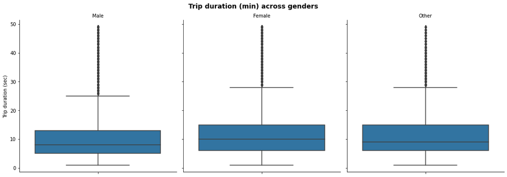

```python
data = gobike_clean.query('duration_min < 50')
g = sb.catplot(data= data, y='duration_min', col="member_gender", kind='box',
            color = default_color)
g.set_titles(col_template = '{col_name}')
g.set_axis_labels("", "Trip duration (sec)")
g.fig.suptitle('Trip duration (min) across genders', y=1.03, fontsize=14, fontweight='semibold');
```

Let's take a look at user type and start month

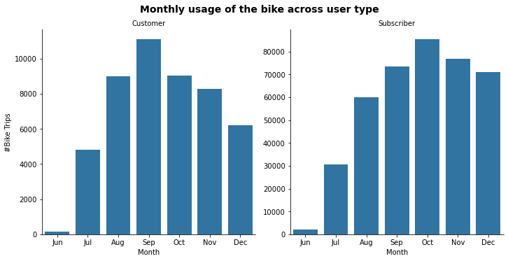

```python
# start month and user type
g = sb.catplot(data=gobike_clean, x='start_month', col="user_type", kind='count', sharey = False,
            color = default_color)
g.set_axis_labels("Month", "#Bike Trips")
g.set_titles("{col_name}")
g.fig.suptitle('Monthly usage of the bike across user type', y=1.03, fontsize=14, fontweight='semibold');
```

##### For customers we see a general increase until September where rides begin to drop off. For Subscribers we see a simialr trend, however there is a peak in October before a much gradual descrease in usage begins.

Let's take a look at user type and start hour

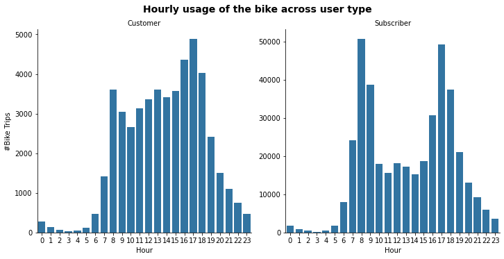

```python
g = sb.catplot(data=gobike_clean, x='start_time_hour', col="user_type", kind='count', sharey = False,
            color = default_color)
g.set_axis_labels("Hour", "#Bike Trips")
g.set_titles("{col_name}")
g.fig.suptitle('Hourly usage of the bike across user type', y=1.03, fontsize=14, fontweight='semibold');
```

##### For both user types we see peaks in the morning at 8am and a peak in the afternoon at 5pm with a gradual drop off. However for the subscriber we see that there is a significant drop off during the middle of the day compared to the customer user type where we have some consistency of levels.

#### Let's take a look at user type and day of week

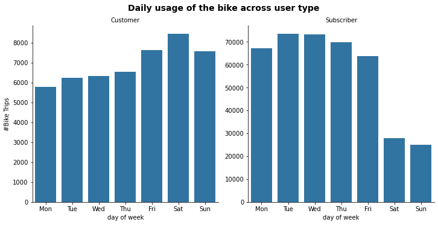

```python
g = sb.catplot(data=gobike_clean, x='start_time_dayofweek', col="user_type", kind='count', sharey = False,
            color = default_color)
g.set_axis_labels("day of week", "#Bike Trips")
g.set_titles("{col_name}")
g.fig.suptitle('Daily usage of the bike across user type', y=1.03, fontsize=14, fontweight='semibold');
```

##### For the customer we see a peak on Saturdays with two other peaks on Friday and Sunday. We see the opposite with the subscriber user type with a significant drop off at the weekends and peak usage on Tuesdays.

Let's take a look at duration in minutes and user type

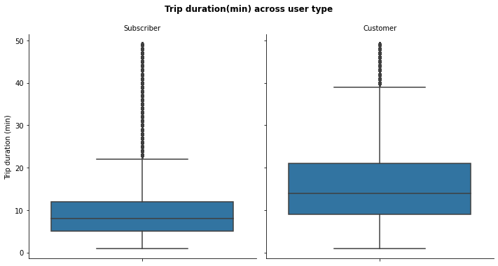

```python
data = gobike_clean.query('duration_min < 50')
g = sb.catplot(data= data, y='duration_min', col="user_type", kind='box',
            color = default_color)
g.set_titles(col_template = '{col_name}')
g.set_axis_labels("", "Trip duration (min)")
g.fig.suptitle('Trip duration(min) across user type', fontweight = 'bold', y=1.05);
```

##### Again some significnt difference between user types. We see customers spending longer periods of time on the bikes compared to subscribers. Bike rides for customers being around 9 to 22 minutes long and subscribers being around 5 to 13 mins long

Let's take a look at ride duration and rider age

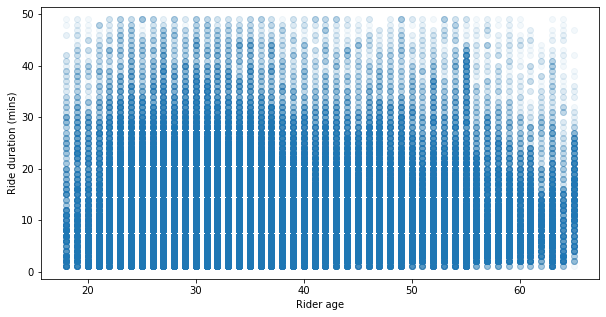

```python
data = gobike_clean.query('duration_min < 50')
plt.figure(figsize = [10, 5])
plt.scatter(data = data, x = 'user_age', y = 'duration_min', alpha=1/20);
plt.xlabel('Rider age')
plt.ylabel('Ride duration (mins)');
```

### Talk about some of the relationships you observed in this part of the investigation. How did the feature(s) of interest vary with other features in the dataset?

> When we looked at the user type we saw some interesting differences between subscriber and customer. For example we saw weekend usage to be peaking for customers but for subscribers it showed the lowest number of trips. This difference was also shown in the trips taken during the day. A significant drop off for subscirbers happened during the middle of the day, where as we saw fairly consistent levels during the day for customers, with simialr peaks between the two at 8am and 5pm.

## Multivariate Exploration

I'll take a further look into the user type as this seems the most promising area to investigate further

Let's take a look at duration of rides across gender and user type

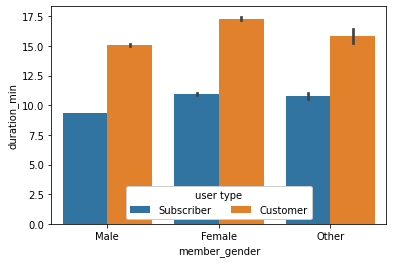

```python
data = gobike_clean.query('duration_min < 50')
ax = sb.barplot(data = data, x = 'member_gender', y = 'duration_min', hue = 'user_type')
ax.legend(loc = 8, ncol = 3, framealpha = 1, title = 'user type');
```

#### Above we can see that across the board customers spend longer on rides that subscribers, with female customers spending the longest time.

Let's take a look at duration of rides across user type and start time day of the week

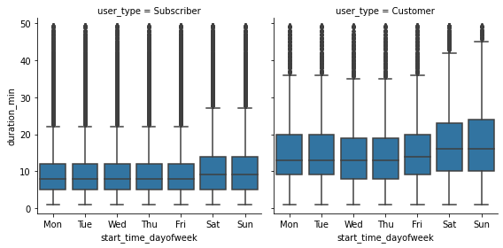

```python
data = gobike_clean.query('duration_min < 50')
g = sb.FacetGrid(data = data, col = 'user_type', height = 4)
g.map(sb.boxplot, 'start_time_dayofweek', 'duration_min')
```

##### For both subscriber and customer we see an increase in duration of rides over the weekend. Subscibers have a fairly consistent ride duration during the week and customers spend a far greater period of time on rides.

Let's take a look at duration of rides across start month and user type

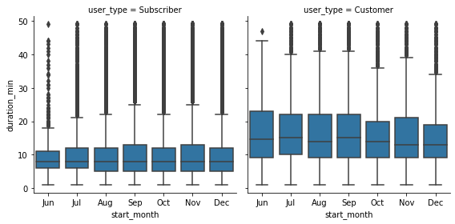

```python
data = gobike_clean.query('duration_min < 50')
g = sb.FacetGrid(data = data, col = 'user_type', height = 4)
g.map(sb.boxplot, 'start_month', 'duration_min')
```

##### Above we can see that like the weekdays, over monthly periods subscribers spend a far shorter period of time on rides.

Let's take a look at start time across user type and gender

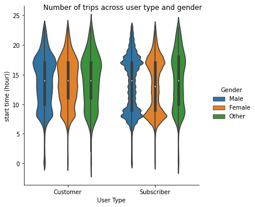

```python
g = sb.catplot(data=gobike_clean, x='user_type', y="start_time_hour", hue="member_gender", kind="violin")

g.set_axis_labels("User Type", "start time (hour))")
g._legend.set_title('Gender')
g.fig.suptitle('Number of trips across user type and gender');
```

##### Above we can see the distribution of subscribers where we see the peaks at 8am and 5pm with a dip during the middle of the day. There appears to be some fluctuations for male subscribers compared to other subscribers. There's a far lesser reduction in rides for customers during the middle of the day.

Let's take a look at start time hour and day of week across user type

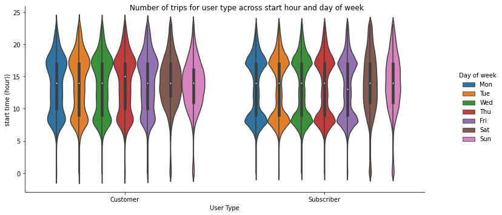

```python
g = sb.catplot(data=gobike_clean, x='user_type', y="start_time_hour", hue="start_time_dayofweek", kind="violin", aspect=2)

g.set_axis_labels("User Type", "start time (hour))")
g._legend.set_title('Day of week')
g.fig.suptitle('Number of trips for user type across start hour and day of week');
```

##### There's some similarity in the increase of midday rides on the weekend for both user types. There's a far greater reduction in rides for subscribers during the midday working week usage compared to customers.

### Talk about some of the relationships you observed in this part of the investigation. Were there features that strengthened each other in terms of looking at your feature(s) of interest?

- Across the board customers spend longer on rides than subscribers, with female customers spending the longest time.
- For both subscriber and customer we see an increase in duration of rides over the weekend. Subscibers have a fairly consistent ride duration during the week and customers spend a far greater period of time on rides.
- We can see that like the weekdays, over monthly periods subscribers spend a far shorter period of time on rides.
- We can see the distribution of subscribers where we see the peaks at 8am and 5pm with a dip during the middle of the day. There's a far lesser reduction in rides for customers during the middle of the working day.
- There's some similarity in the increase of midday rides on the weekend for both user types. There's a far greater reduction in rides for subscribers during the midday working week usage compared to customers

### Were there any interesting or surprising interactions between features?

- There appears to be some fluctuations for male subscribers in the violin plot compared to other subscribers.